# 06_analysis_2

Author

Eric Torres, Lucía de Lamadrid, Konstantina Gkopi, Elena Iriondo and Jorge Santiago

### Principal Component Analysis on Phylum-Level Aggregated Microbiome Data

In this section, we perform PCA on microbiome data aggregated at the phylum level. We aim to identify key axes of variation and visualize sample clustering to uncover patterns in microbial community composition. To reduce the complexity of the data, we will work solely on first generation humanised mice, studying how diet and microbiota composition at the phylum level structures the data.

#### 1. **Load libraries**

```r
library("tidyverse")
library("broom")
library("ggrepel")
library("ggthemes")
library("cowplot")
```

#### 2. Load data for PCA

To perform PCA, we use the wide aggregated microbiome data in which the relative abundances within each phylum are summed. This reduces dimensionality while retaining relevant biological information. In order to subject it to the PCA, we will also have to one-hot encode the Diet column, as this method only allows for numerical variables. Regarding the other columns, we will not include them in the analysis as the classes for this experiment are very imbalanced (e.g. no female mice, only cecum and fecal samples were obtained from first generation humanized mice, etc.).

```r
aggregated_wide <- read_tsv("../data/03_metadata_wide_phylum.tsv")
```

```r
aggregated_wide <- aggregated_wide |>
  filter(Donor == "Fresh" ) |>
  mutate( Diet = case_when(Diet == "LFPP" ~ 0, Diet == "Western" ~ 1) ) #pca uses numerical values so we modify the diet column

head(aggregated_wide)
```

```
# A tibble: 6 × 10
  SampleID  Diet Donor Actinobacteria Bacteroidetes Firmicutes Proteobacteria
     <dbl> <dbl> <chr>          <dbl>         <dbl>      <dbl>          <dbl>
1      339     1 Fresh        0.00316        0.463       0.470        0.00671
2      340     1 Fresh        0.0180         0.106       0.811        0.00138
3      341     1 Fresh        0.0121         0.0443      0.873        0.00792
4      342     1 Fresh        0.00531        0.145       0.786        0.0135
5      343     1 Fresh        0.00801        0.607       0.300        0.0300
6      344     1 Fresh        0.631          0.199       0.141        0.00467
# ℹ 3 more variables: TM7 <dbl>, Unclassified <dbl>, Verrucomicrobia <dbl>
```

#### 3. Performing PCA

Using the aggregated data, we scale the phylum-level abundances and apply PCA. This identifies the key axes of variation in the dataset, summarizing complex microbial community structures into principal components.

```r
# Scale the aggregated data and perform PCA
otu_data_pca <- aggregated_wide |>
  select(-SampleID, -Donor) |> #remove the sample id column as this categorical variable adds no information (it's the same as a row count in this case)
  scale() |>
  prcomp()
```

#### 4. Explaining Variance

To understand how much of the dataset’s variability is captured by each principal component, we analyze the explained variance.

```r
pca_variance <- otu_data_pca |>
  tidy(matrix = "eigenvalues")

pca_variance
```

```
# A tibble: 8 × 4
     PC std.dev percent cumulative
  <dbl>   <dbl>   <dbl>      <dbl>
1     1  1.76   0.389        0.389
2     2  1.15   0.164        0.553
3     3  1.03   0.133        0.687
4     4  0.991  0.123        0.809
5     5  0.943  0.111        0.921
6     6  0.607  0.0461       0.967
7     7  0.514  0.0330       1.00
8     8  0.0483 0.00029      1
```

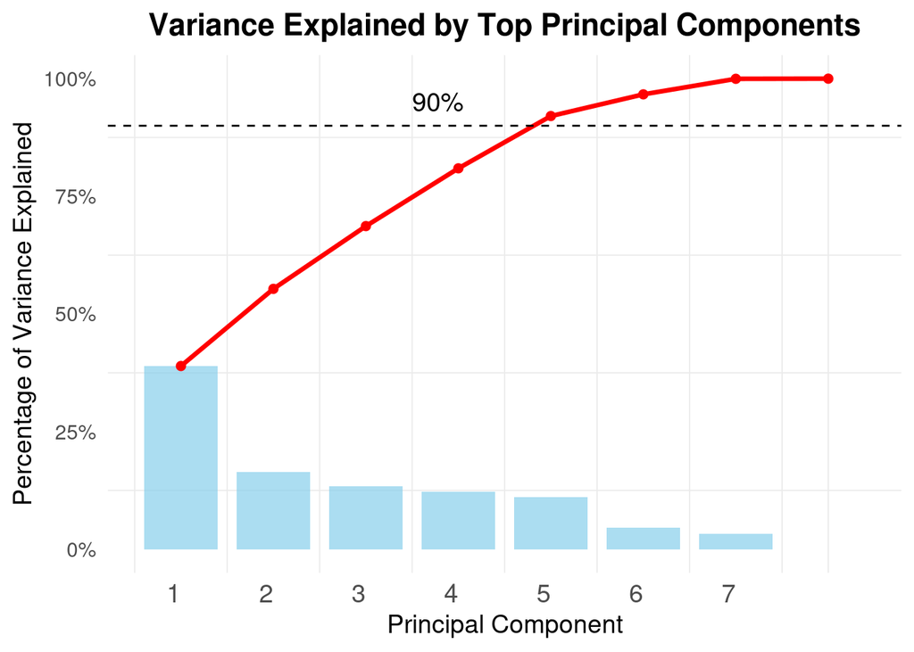

```r
# Plot variance explained by PCs
pca1 <- ggplot(pca_variance, aes(x = PC, y = percent)) +
  geom_bar(stat = "identity", fill = "skyblue", alpha = 0.7, width = 0.8) +
  geom_line(aes(y = cumulative), color = "red", size = 1.2, group = 1) +
  geom_point(aes(y = cumulative), color = "red", size = 2) +
  labs(
    title = "Variance Explained by Top Principal Components",
    x = "Principal Component",
    y = "Percentage of Variance Explained"
  ) +
  scale_x_continuous(breaks = 1:7) +
  scale_y_continuous(labels = scales::percent_format(accuracy = 1)) +
  theme_minimal(base_size = 14) +
  theme(
    plot.title = element_text(hjust = 0.5, face = "bold"),
    axis.text.x = element_text(angle = 0, hjust = 1, size = 14),
    axis.title.y = element_text(size = 14),
    panel.grid.major = element_blank(),
  ) +
  geom_hline(yintercept = 0.9, linetype = "dashed", size = 0.5) + # Add line at 90% variance explained
  annotate("text", x = 3.5, y = 0.95, label = "90%", size = 5, hjust = 0) #we add an annotation with the 90%
pca1
```

```r
ggsave("../results/pca_variance.png",
       plot = pca1,
       width = 8,
       height = 6,
       units = "in",
       bg = "white")
```

The PCA variance table shows that PC1 and PC2 together explain 55.34% of the total variance, with PC1 accounting for 38.94% and PC2 for 16.40%. Including PC3, PC4 and PC5 increases the cumulative explained variance to 92.06%, capturing most of the dataset’s variability. Variance contributions drop significantly for subsequent components, making PC1 and PC2 the most relevant for analysis. This highlights the effectiveness of PCA in summarizing key microbial variation driven by diet and phylum-level differences.

#### 5. **Visualizing PC1 vs PC2**

We plot the first two principal components (PC1 and PC2) to visualize the differences between diets.

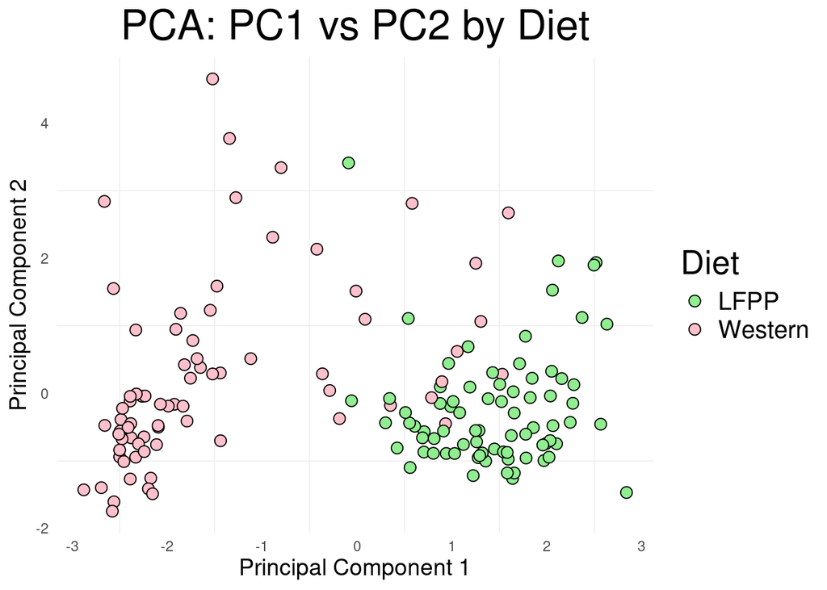

```r
pca2 <- otu_data_pca |>
  augment(aggregated_wide) |>
  ggplot(aes(.fittedPC1, .fittedPC2, fill = factor(Diet))) +  # Map fill to factor
  geom_point(size = 3, shape = 21) +                          # Adjust point size and shape
  scale_fill_manual(                                         # Manually define colors and labels
    values = c("0" = "light green", "1" = "pink"),                   # Assign colors to Diet levels
    name = "Diet",                                           # Legend title
    labels = c("LFPP", "Western")                    # Legend labels
  ) +
  labs(
    title = "PCA: PC1 vs PC2 by Diet",
    x = "Principal Component 1",
    y = "Principal Component 2"
  ) +
  theme_minimal() +
  theme(
    panel.grid.major = element_blank(),
    legend.position = "right",
    plot.title = element_text(size = 25, hjust = 0.5),
    legend.title = element_text(size = 20),
    legend.text = element_text(size = 15),
    axis.title.x = element_text(size = 14),
    axis.title.y = element_text(size = 14)
  )

pca2
```

```r
ggsave("../results/pc1vspc2.png",
       plot = pca2,
       width = 8,
       height = 6,
       units = "in",
       bg = "white")
```

The plot shows clear clustering according to diet, with observations of the LFPP diet accumulating on the lower right corner of the grid.

#### 6. **Understanding contributions to PC1 and PC2**

Now, we will represent the individual contributions of each variable to the first two principal components. Analysing the contributions of individual phyla to the first two principal components can allow us to identify key taxa driving variation in the data. This provides biological insights into which phyla influence microbiome differences.

```r
# Define arrow style for plotting
arrow_style <- arrow(
  angle = 25, ends = "first", type = "closed", unit(0.2, "cm")
)
rotation_matrix <- otu_data_pca |> tidy(matrix = "rotation")

rotation_pivot <- rotation_matrix |>
  filter(PC %in% c(1, 2)) |>
  pivot_wider(names_from = "PC", names_prefix = "PC", values_from = "value")

# Print to confirm the structure
print(rotation_pivot)
```

```
# A tibble: 8 × 3
  column              PC1     PC2
  <chr>             <dbl>   <dbl>
1 Diet            -0.474   0.186
2 Actinobacteria  -0.0287 -0.0287
3 Bacteroidetes    0.514   0.277
4 Firmicutes      -0.502  -0.307
5 Proteobacteria  -0.0409  0.726
6 TM7              0.163  -0.0376
7 Unclassified     0.463  -0.254
8 Verrucomicrobia -0.124   0.447
```

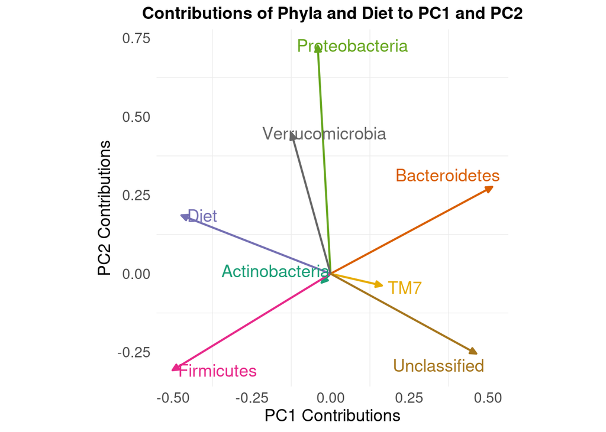

```r
pca3 <- ggplot(rotation_pivot, aes(x = PC1, y = PC2, color = column)) +
  geom_segment(aes(xend = 0, yend = 0), arrow = arrow_style, size = 0.8) +
  scale_color_brewer(palette = "Dark2") +
  geom_text_repel(aes(label = column), size = 5, hjust = 1) +
  labs(
    title = "Contributions of Phyla and Diet to PC1 and PC2",
    x = "PC1 Contributions",
    y = "PC2 Contributions",
    color = "Phylum"
  ) +
  coord_fixed() +
  theme_minimal() +
  theme(
    plot.title = element_text(size = 14, face = "bold", hjust = 0.5),
    axis.text = element_text(size = 12),
    axis.title = element_text(size = 14),
    legend.position = "none",
    axis.title.x = element_text(size = 14),
    axis.title.y = element_text(size = 14),
    panel.grid.major = element_blank()
  )

pca3
```

```r
ggsave("../results/pca_contributions.png",
       plot = pca3,
       width = 8,
       height = 6,
       units = "in",
       bg = "white")
```

The biplot illustrates the contributions of the variables to the first two principal components (PC1 and PC2). From this, we can extract several conclusions:

- Western diet (Diet=1) correlates with a negative PC1 coordinate, which is in line with Western diet observations being found on the left of the previous scatter plot. It also contributes to PC2, but to a lower extent.
- **Unclassified** phyla present an opposite behavior to the diet variable. This is in line with the barplots presented in the description section, which showed more OTUs from unclassified phyla could be found in the LFPP diet.
- **Bacteroidetes** and **Firmicutes** also exhibit opposite behaviors, consistent with their biological significance. As explained in other sections, the ratio of Firmicutes to Bacteroidetes serves as a well-established marker for obesity.
- **Verrucomicrobia** and **Proteobacteria** cluster together, contributing to PC2.
- **TM7** and **Actinobacteria** present vectors of a much smaller magnitude due to the fact that the relative abundance of OTUs belonging to these phyla vary less. Furthermore, Actinobacteria has the same direction as Firmicutes, in line with the data description results.

This plot emphasizes that a few dominant phyla drive the main axes of variation in microbial communities, underscoring the importance of these phyla in shaping the microbial composition and potentially influencing host health outcomes.

### Analysis of Microbiome Clusters by Donor Groups Using Hierarchical Clustering

Hierarchical clustering, on the other hand, allowed us to group microbiota profiles into well-defined clusters based on similarity, making it easier to interpret patterns within and across donor groups. By combining this with statistical tests (e.g., chi-squared test), we could confirm the significance of the associations between donor origins and microbiota clusters, providing a more detailed understanding of the data.

#### 1. Data Preparation

For this analysis we will use the 02_metadata_wide_filtered_label.tsv” data frame, that contains metadata and OTU counts for each sample.

```r
# Read the metadata in wide format
filtered_metadata_wider <- read_tsv("../data/02_metadata_wide_filtered_label.tsv")
```

```r
# Select OTU columns
otu_data <- filtered_metadata_wider |>
  select(starts_with("OTU"))

# Check the dimensions of the OTU data
dim(otu_data)
```

```
[1] 675 392
```

#### **Standardization**

To ensure clustering algorithms work effectively, we standardize the OTU data. This ensures all features are on the same scale.

```r
# Scale the OTU data
otu_data_scaled <- otu_data |>
  scale()

# Convert scaled matrix back to tibble for tidyverse compatibility
otu_data_scaled <- as_tibble(otu_data_scaled)
```

We add the relevant metadata, in this case “Donor”, as we will use it later in our analysis.

```r
# Add relevant metadata (e.g., Donor)
otu_data_with_metadata <- otu_data_scaled |>
  mutate(Donor = filtered_metadata_wider |> pull(Donor))
```

#### 2. Hierarchical Clustering

We compute a **distance matrix** using the Euclidean distance to measure similarity between microbiome samples. The clustering is performed using **Ward’s method**, which minimizes variance within clusters.

```r
# Compute Euclidean distance matrix
dist_matrix <- otu_data_scaled |>
  dist()
# Perform hierarchical clustering
hclust_result <- hclust(dist_matrix, method = "ward.D2")
```

#### **Cluster Assignment**

We cut the dendrogram into three clusters and assign cluster labels to the metadata. This step groups samples based on the similarity of their OTU profiles.

```r
# Cut dendrogram into 3 clusters
cluster_labels <- cutree(hclust_result, k = 3) |>
  as_tibble() |>
  rename(Cluster = value)

# Attach cluster labels to metadata
clustered_metadata <- filtered_metadata_wider |>
  mutate(Cluster = cluster_labels |> pull(Cluster))
```

#### 3. **Donor Distribution Across Clusters**

To understand the relationship between clusters and donor groups, we summarize the distribution of donors within each cluster. This helps identify patterns of donor contributions.

```r
# Summarize cluster-donor relationships
cluster_metadata_summary <- clustered_metadata |>
  group_by(Cluster, Donor) |>
  summarize(Count = n(), .groups = "drop") |>
  group_by(Cluster) |>
  mutate(Proportion = Count / sum(Count))

# View the summary
cluster_metadata_summary
```

```
# A tibble: 11 × 4
# Groups:   Cluster [3]
   Cluster Donor         Count Proportion
     <int> <chr>         <int>      <dbl>
 1       1 CONVR             7     0.0135
 2       1 Fresh            97     0.188
 3       1 Frozen           92     0.178
 4       1 HMouseLFPP      287     0.555
 5       1 HMouseWestern    28     0.0542
 6       1 Human             6     0.0116
 7       2 Fresh            54     0.551
 8       2 HMouseLFPP       26     0.265
 9       2 HMouseWestern    18     0.184
10       3 CONVD             3     0.05
11       3 CONVR            57     0.95
```

#### **Visualization**

We use a bar plot to visualize the proportion of donor groups within each cluster. This reveals how donors contribute to the composition of each cluster.

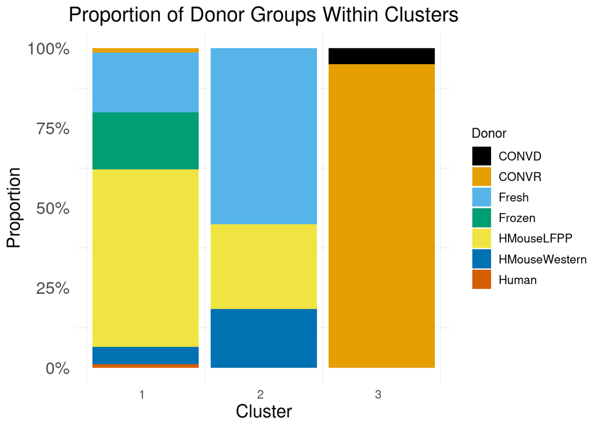

```r
# Bar plot showing donor proportions within each cluster
clusters <- ggplot(cluster_metadata_summary, aes(x = Cluster, y = Proportion, fill = Donor)) +
  geom_bar(stat = "identity", position = "fill") +
  scale_y_continuous(labels = scales::percent) +
  scale_fill_colorblind() +
  labs(
    title = "Proportion of Donor Groups Within Clusters",
    x = "Cluster",
    y = "Proportion",
    fill = "Donor"
  ) +
  theme_minimal() +
  theme(
    panel.grid.major = element_blank(),
    legend.text = element_text(size = 10),
    axis.text.x = element_text(size = 10, hjust = 1),
    axis.text.y = element_text(size = 14),
    axis.title.x = element_text(size = 15),
    axis.title.y = element_text(size = 15),
    plot.title = element_text(hjust = 0.5, size = 17),
  )


clusters
```

```r
ggsave("../results/clusters.png", plot = clusters, width = 8, height = 6, units = "in", bg = "white")
```

#### 4. **Statistical Association Between Donor and Cluster**

We simplify the donor groups by grouping less frequent donors under “Other” to streamline the analysis. A contingency table is created to summarize the relationship between donor groups and clusters.

```r
# Simplify donor groups and create a contingency table
clustered_metadata <- clustered_metadata |>
  mutate(Donor = case_when(
    Donor %in% c("Human", "HMouseWestern", "CONVD" ) ~ "Other",
    TRUE ~ Donor
  ))
donor_cluster_table <- clustered_metadata |>
  count(Cluster, Donor) |>
  pivot_wider(names_from = Donor, values_from = n, values_fill = 0) |>
  column_to_rownames("Cluster") |>
  as.matrix()
```

#### **Chi-Squared Test**

A chi-squared test is performed on the contingency table to determine whether donor distributions across clusters are statistically significant.

```r
# Perform chi-squared test
chi2_result <- chisq.test(donor_cluster_table)
chi2_result
```

```
    Pearson's Chi-squared test

data:  donor_cluster_table
X-squared = 659.91, df = 8, p-value < 2.2e-16
```

The hierarchical clustering results reveal distinct donor distributions. **Cluster 1** is dominated by **HMouseLFPP** (55.5%) with notable contributions from **Frozen** (17.8%) and **Fresh** (18.7%), reflecting plant-rich diets and preserved samples. **Cluster 2** includes mostly **Fresh** (55.1%) and **HMouseLFPP** (26.5%), indicating a mix of human-derived and dietary influences. **Cluster 3** is almost entirely **CONVR** (95%), representing natural microbiota from control mice. The chi-squared test (p-value < 2.2e-16) confirms significant associations between donor origins and clusters, highlighting the influence of donors on microbiota composition.